# Evaluate {EpiEstim} on five epidemic outbreaks

LiJin Joo lijin.joo at gmail.com

2020-08-23

(Cori et al. 2013) used the following five examples to demonstrate {EpiEstim} in thier paper. As the first step of {EpiEstim} evalution, we reproduced Figure1 and generated a table summarize the comparison of the current version and the result resported in Cori et al.

```r
library(EpiEstim)
library(ggplot2)

data(Measles1861)
data(Flu1918)
data(Smallpox1972)
data(SARS2003)
data(Flu2009)
```

Each data containis at least two varriables, a serise of number of cases (i.e. incidence) and a distirbution of serial intervals (i.e. si_distr) as in Flu 2009.

```r
head(Flu2009$incidence)
```

```
##        dates I
## 1 2009-04-27 1
## 2 2009-04-28 1
## 3 2009-04-29 0
## 4 2009-04-30 2
## 5 2009-05-01 5
## 6 2009-05-02 3
```

```r
Flu2009$si_distr
```

```
##  [1] 0.000 0.233 0.359 0.198 0.103 0.053 0.027 0.014 0.007 0.003 0.002 0.001
```

Several options are available for different estimators for a distribution of serial intervals in {EpiEstim}: 1) `nonparametric_si' with the supplied density weights (si_distr), 2)`parametric_si’ with options in `contig', such as mean_si, std_si, or 3) learning a distribution of serial intervals from data or samples using mcmc through`make_contig’ function. Details of each option can be learned from (“EpiEstim: The R-Epi Project” 2020), (“EpiEstim: Github Repository” 2020), (Anne Cori 2020).

### Reproducing Figure 1

With the provided si_distr, we can obtain Rt estimates non-parametrically with a default of 7 day sliding window as follows:

```r
Rt_measles1861 <- estimate_R(incid = Measles1861$incidence,
                         method = "non_parametric_si",
                         config = make_config(list(si_distr = Measles1861$si_distr)))

round(head(Rt_measles1861$R[,c(1:4, 5, 8, 11)], 15), 1)
```

```
##    t_start t_end Mean(R) Std(R) Quantile.0.025(R) Median(R) Quantile.0.975(R)
## 1        2     8      NA     NA                NA        NA                NA
## 2        3     9      NA     NA                NA        NA                NA
## 3        4    10      NA     NA                NA        NA                NA
## 4        5    11      NA     NA                NA        NA                NA
## 5        6    12      NA     NA                NA        NA                NA
## 6        7    13      NA     NA                NA        NA                NA
## 7        8    14      NA     NA                NA        NA                NA
## 8        9    15     8.2    2.9               3.5       7.8              14.7
## 9       10    16     5.1    2.1               1.9       4.8               9.9
## 10      11    17     5.1    1.9               2.0       4.8               9.5
## 11      12    18     4.5    1.7               1.8       4.2               8.3
## 12      13    19     4.5    1.6               2.0       4.3               8.2
## 13      14    20     3.6    1.3               1.4       3.4               6.6
## 14      15    21     3.2    1.2               1.3       3.0               5.9
## 15      16    22     3.6    1.2               1.7       3.5               6.4
```

```r
Rt_flu1918 <- estimate_R(incid = Flu1918$incidence,
                         method = "non_parametric_si",
                         config = make_config(list(si_distr = Flu1918$si_distr)))

round(head(Rt_flu1918$R[,c(1:4, 5, 8, 11)]),1)
```

```
##   t_start t_end Mean(R) Std(R) Quantile.0.025(R) Median(R) Quantile.0.975(R)
## 1       2     8     1.4    0.2               1.0       1.4               1.9
## 2       3     9     1.2    0.2               0.9       1.2               1.6
## 3       4    10     1.4    0.2               1.0       1.4               1.7
## 4       5    11     1.0    0.2               0.7       1.0               1.3
## 5       6    12     1.3    0.2               1.0       1.3               1.6
## 6       7    13     1.2    0.2               0.9       1.2               1.6
```

```r
Rt_Smallpox1972 <- estimate_R(incid = Smallpox1972$incidence,
                              method = "non_parametric_si",
                              config = make_config(list(si_distr = Smallpox1972$si_distr)))

round(head(Rt_Smallpox1972$R[,c(1:4, 5, 8, 11)], 10),1)
```

```
##    t_start t_end Mean(R) Std(R) Quantile.0.025(R) Median(R) Quantile.0.975(R)
## 1        2     8      NA     NA                NA        NA                NA
## 2        3     9      NA     NA                NA        NA                NA
## 3        4    10      NA     NA                NA        NA                NA
## 4        5    11      NA     NA                NA        NA                NA
## 5        6    12      NA     NA                NA        NA                NA
## 6        7    13      NA     NA                NA        NA                NA
## 7        8    14      NA     NA                NA        NA                NA
## 8        9    15      NA     NA                NA        NA                NA
## 9       10    16      NA     NA                NA        NA                NA
## 10      11    17      NA     NA                NA        NA                NA
```

```r
Rt_sars2003 <- estimate_R(incid = SARS2003$incidence,
                          method = "non_parametric_si",
                          config = make_config(list(si_distr = SARS2003$si_distr)))

round(head(Rt_sars2003$R[,c(1:4, 5, 8, 11)]), 1)
```

```
##   t_start t_end Mean(R) Std(R) Quantile.0.025(R) Median(R) Quantile.0.975(R)
## 1       2     8      NA     NA                NA        NA                NA
## 2       3     9     5.8    2.4               2.1       5.4              11.2
## 3       4    10     6.0    2.1               2.6       5.8              10.9
## 4       5    11     4.8    1.7               2.1       4.6               8.7
## 5       6    12     4.3    1.4               2.0       4.2               7.6
## 6       7    13     3.9    1.2               1.9       3.7               6.6
```

```r
Rt_flu2009 <- estimate_R(incid = Flu2009$incidence$I,
                         method = "non_parametric_si",
                         config = make_config(list(si_distr = Flu2009$si_distr)))
round(head(Rt_flu2009$R[,c(1:4, 5, 8, 11)]), 1)
```

```
##   t_start t_end Mean(R) Std(R) Quantile.0.025(R) Median(R) Quantile.0.975(R)
## 1       2     8     1.7    0.4               1.0       1.7               2.6
## 2       3     9     1.7    0.4               1.1       1.7               2.5
## 3       4    10     1.5    0.3               1.0       1.5               2.2
## 4       5    11     1.4    0.3               1.0       1.4               2.0
## 5       6    12     1.4    0.3               1.0       1.4               2.0
## 6       7    13     1.6    0.3               1.2       1.6               2.2
```

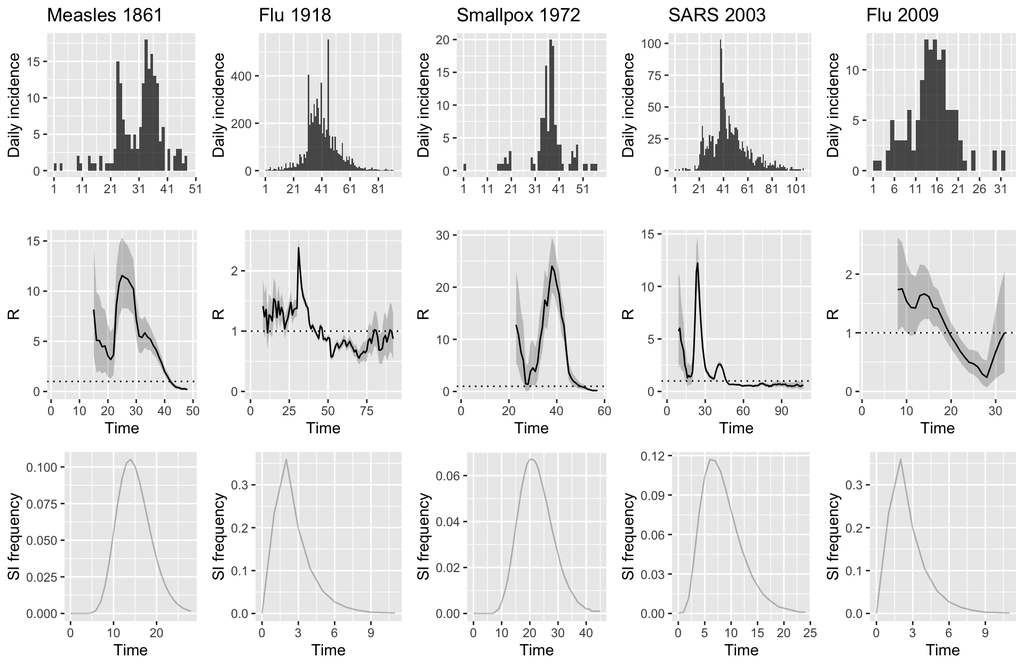

### Comparison

Over the years, some features of {EpiEstim} have been updated thus minor differences are observed. Characteristics of each case curve and differences in the reproduced numbers are summarized as follows.

[output not shown]

- Reproduced estimates are sample quantiles, median (quanteil at 0.025 - quantile at 0.975).
- 95Q indicates 95 sample quantile intervals. Cori et al. used a term of 95% CI but it seems they referring to the quantile intervals.
- d indicates t_end in R_t result.

### Conclusion

With fixed serial interval weights, the estimates are consistent in the reproducible studies.

A true challenge in a COVID 19 study is to obtain an sensible estimate for this distribution.

### Reference

Anne Cori, Neil M. Ferguson, Simon Cauchemez. 2020. *EpiEstim: Estimate Time Varying Reproduction Numbers from Epidemic Curves*. https://cran.r-project.org/web/packages/EpiEstim/index.html.

Cori, Anne, Neil M Ferguson, Christophe Fraser, and Simon Cauchemez. 2013. “A New Framework and Software to Estimate Time-Varying Reproduction Numbers During Epidemics.” *American Journal of Epidemiology* 178 (9). Oxford University Press: 1505–12.

“EpiEstim: Github Repository.” 2020. https://github.com/mrc-ide/EpiEstim.

“EpiEstim: The R-Epi Project.” 2020. https://sites.google.com/site/therepiproject/r-pac/epiestim.